# 五大联赛转会流动与足球集团化分析

## 准备工作

```r
library(rmdformats)
library(dplyr)
library(tidyr)
library(stringr)
library(ggplot2)
library(ggalluvial)
library(gridExtra)
library(waffle)
```

## 1. 背景介绍

2024年1月1日，欧洲足坛照常开启了23/24赛季的冬季转会窗，对于跨年进行的欧洲各大俱乐部赛事来说，这是本赛季内唯一一次可以对阵容进行大范围调整的机会。在2023年冬季转会窗，五大联赛球队共支出了10.61亿欧元。  
具体来说，足球转会窗口是指俱乐部可以签约新球员或者出售现有球员的特定时间段，一般分为夏季转会窗口和冬季转会窗口，简称夏窗和冬窗。在转会窗口内，通常有两种交易球员的方式，分别为永久转会（Transfer）和租借（Loan）。永久转会是指球员离开原俱乐部，与新俱乐部签订合同；而租借是指一个俱乐部将其球员暂时租借给另一支俱乐部使用，球员在租借期间仍然是原俱乐部的注册球员，在期满后会返回原俱乐部。而五大联赛通常是指欧洲影响力及竞技水平排名前五的足球联赛，代表了欧洲足球最高的声望和技战术水平。一般而言，这五个联赛包括英格兰足球超级联赛（英超，Premier League）、西班牙足球甲级联赛（西甲，La Liga）、意大利足球甲级联赛（意甲，Serie A）、德国足球甲级联赛（德甲，Bundesliga）和法国足球甲级联赛（法甲，Ligue 1）。  
近10年以来，欧洲足坛的一大趋势为足球集团化，具体表现为由一家跨国公司在全球范围内拥有和管理多个足球俱乐部。通过足球集团化，各俱乐部能够最大程度的共享资源、协同发展，从而提高俱乐部的整体实力，并在足球领域取得商业成功。  
目前最大的两个足球集团分别为城市足球集团（City Football Group，CFG）和红牛集团（Red Bull Group）。其中前者由阿布扎比联合集团（Abu Dhabi United Group）控股，总部位于英格兰曼彻斯特，拥有英超球队曼彻斯特城、西甲球队赫罗纳、中超球队深圳新鹏城（前四川九牛）等多家足球俱乐部；后者由奥地利的红牛公司创建，拥有德甲球队RB莱比锡（RB Leipzig）等。  
值得注意的是，足球集团内部训练方法等资源的共享往往是不可见的，人事方面的内部调整也往往不足够透明，因此，转会窗为我们了解足球集团化的效果提供了公开的数据。理论上，集团内的球队会由于管理层的亲密而倾向于互相交易，集团内的相对较差球队能够以更实惠的价格买到心仪的球员，相对较好的球队也能够更方便地派遣小将外出锻炼提升。  
通过足球转会窗口，我们不仅能够通过交易了解每支球队的战术调整和运营策略，揭示各球队之间的交流与竞争关系，还能够整体性地得以窥见各个联赛之间的互动和差异，从而对整个欧洲足球的发展态势有所了解。

## 2. 数据来源与说明

### 2.1 读取并整理数据

```r
# .csv文件列表（和.Rmd在同一路径下）
file_list <- c("S-D.csv", "S-A.csv", "LL-D.csv", "PL-A.csv", "PL-D.csv", "L-A.csv", "L-D.csv", "LL-A.csv", "B-A.csv", "B-D.csv")

# 定义.csv文件读取函数
process_file <- function(file) {
  df <- read.csv(file, header = TRUE)
  # 根据文件名定义转会Type为Departures或Arrivals
  df$Type <- ifelse(grepl("-D.csv", file), "Departures", "Arrivals")
  # 获取连字符前的联赛名简称
  competition <- strsplit(file, "-")[[1]][1]
  # 建立联赛简称全称对应
  competition_mapping <- c("S" = "Serie A", "LL" = "LaLiga", "PL" = "Premier League", "L" = "Ligue 1", "B" = "Bundesliga")
  # 定义Competition0代表本方联赛（本方：球员转入该联赛该球队；球员从该联赛该球队转出）
  df$Competition0 <- competition_mapping[competition]
  # 修改变量名，Rank代表转会人次在交易方中的排名，Club0代表本方球队，Competition代表交易方联赛
  colnames(df)[colnames(df) == "字段"] <- "Rank"
  colnames(df)[colnames(df) == "文本"] <- "Club0"
  colnames(df)[colnames(df) == "Competition_2324"] <- "Competition"
  # 删除无关数据列
  df <- df[, -c(3, 5, 7)]
  # 去除球队名的空字符串
  df$Club <- trimws(df$Club)
  df$Club0 <- trimws(df$Club0)
  # 去除Transfers中的租借数据，仅包含永久转会数据
  df$Transfers <- df$Transfers - df$Loans
  # 得到整理后的最终数据集
  return(df)
}
```

```r
# 分别读取五大联赛常驻球队转入转出情况的10个.csv文件
S_D <- process_file("S-D.csv")
S_A <- process_file("S-A.csv")
LL_D <- process_file("LL-D.csv")
PL_A <- process_file("PL-A.csv")
PL_D <- process_file("PL-D.csv")
L_A <- process_file("L-A.csv")
L_D <- process_file("L-D.csv")
LL_A <- process_file("LL-A.csv")
B_A <- process_file("B-A.csv")
B_D <- process_file("B-D.csv")

# 分别合并转入和转出数据
A_merged <- rbind(S_A, PL_A, L_A, LL_A, B_A)
D_merged <- rbind(S_D, PL_D, L_D, LL_D, B_D)
```

## 3. 数据分析

### 3.1 五大联赛常驻球队

#### 3.1.1 转入数据处理

```r
# 统计五大联赛常驻球队的转入总人次
Clubs <- A_merged %>%
  # 按本方球队、本方联赛分组
  group_by(Club0, Competition0) %>%
  # 加总转入总人次
  summarize(Transfers = sum(Transfers, na.rm = TRUE)) %>%
  # 去重
  distinct(Club0, Competition0, Transfers)

# 统计五大联赛的常驻球队数量和转入总人次
Competitions <- Clubs %>%
  # 按本方联赛分组
  group_by(Competition0) %>%
  # 加总常驻球队球队数量、转入总人次
  summarize(constant = n(), SumT = sum(Transfers)) %>%
  # 计算非常驻球队数量（英超、西甲、意甲共20支球队，其他联赛共18支球队）
  mutate(other = ifelse(Competition0 %in% c("Premier League", "LaLiga", "Serie A"),
                        20 - constant, 18 - constant)) %>%
  # 按常驻球队比例排序
  arrange(constant / (constant + other)) %>%
  # 转换数据格式，分行列示常驻和非常驻球队数量
  pivot_longer(cols = c(constant, other), names_to = "type", values_to = "n")

# 将联赛名转为因子变量
Competitions$Competition0 <- factor(Competitions$Competition0, levels = c("Serie A", "LaLiga", "Premier League", "Ligue 1", "Bundesliga"))
# 将球队类别转为因子变量
Competitions$type <- factor(Competitions$type, levels = c("other", "constant"))

# 合并总转入数据，得到每支五大联赛常驻球队的所属联赛、总转入人次、转入交易方球队数量、所属联赛常驻球队总转入人次
A <- Clubs %>%
  # 合并球队转入交易方球队数量
  left_join(A_merged %>% group_by(Club0) %>% summarize(n_clubs = n()), by = "Club0") %>%
  # 所属联赛常驻球队总转入人次
  left_join(Competitions %>% filter(type == "constant") %>% select(Competition0, SumT), by = "Competition0")
```

#### 3.1.2 转出数据处理

```r
# 统计五大联赛常驻球队的转出总人次
Clubs <- D_merged %>%
  # 按本方球队、本方联赛分组
  group_by(Club0, Competition0) %>%
  # 加总转出总人次
  summarize(Transfers = sum(Transfers, na.rm = TRUE)) %>%
  # 去重
  distinct(Club0, Competition0, Transfers)

# 统计五大联赛的常驻球队数量和转出总人次
Competitions <- Clubs %>%
  # 按本方联赛分组
  group_by(Competition0) %>%
  # 加总常驻球队球队数量、转出总人次
  summarize(constant = n(), SumT = sum(Transfers)) %>%
  # 计算非常驻球队数量（英超、西甲、意甲共20支球队，其他联赛共18支球队）
  mutate(other = ifelse(Competition0 %in% c("Premier League", "LaLiga", "Serie A"),
                        20 - constant, 18 - constant)) %>%
  # 按常驻球队比例排序
  arrange(constant / (constant + other)) %>%
  # 转换数据格式，分行列示常驻和非常驻球队数量
  pivot_longer(cols = c(constant, other), names_to = "type", values_to = "n")

# 将联赛名转为因子变量
Competitions$Competition0 <- factor(Competitions$Competition0, levels = c("Serie A", "LaLiga", "Premier League", "Ligue 1", "Bundesliga"))
# 将球队类别转为因子变量
Competitions$type <- factor(Competitions$type, levels = c("other", "constant"))

# 合并总转出数据，得到每支五大联赛常驻球队的所属联赛、总转出人次、转出交易方球队数量、所属联赛常驻球队总转出人次
D <- Clubs %>%
  # 合并球队转出交易方球队数量
  left_join(D_merged %>% group_by(Club0) %>% summarize(n_clubs = n()), by = "Club0") %>%
  # 所属联赛常驻球队总转出人次
  left_join(Competitions %>% filter(type == "constant") %>% select(Competition0, SumT), by = "Competition0")
```

#### 3.1.3 绘制常驻球队占比柱状图

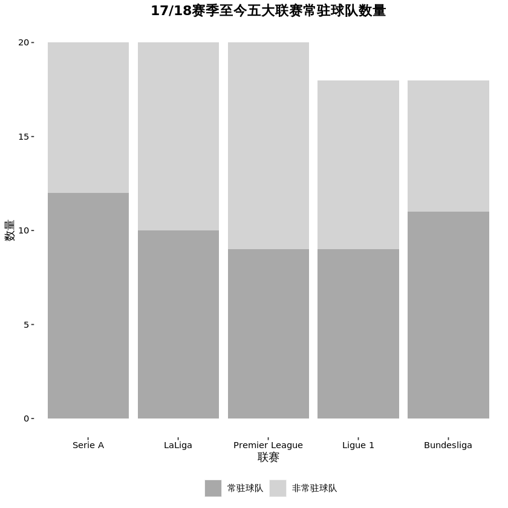

```r
ggplot(Competitions, aes(x = Competition0, y = n, fill = type)) +
  geom_bar(stat = "identity", position = "stack") + # 绘制堆叠柱状图
  scale_fill_manual(values = c("constant" = "darkgrey", "other" = "lightgrey"),
                    labels = c("constant" = "常驻球队", "other" = "非常驻球队")) + #设置绘制颜色
  labs(title = "17/18赛季至今五大联赛常驻球队数量", # 设置标题
       x = "联赛", y = "数量") + # 设置x轴标签和y轴标签
  theme(plot.title = element_text(hjust = 0.5, face = "bold"), # 设置标题文本格式
        text = element_text(family = "Songti SC"), # 设置文本字体
        panel.background = element_rect(fill = "white", color = NA), # 设置绘图背景
        panel.border = element_rect(fill = NA, color = NA), # 设置绘图边框
        axis.text = element_text(color = "black"), # 设置轴文本颜色
        legend.position = "bottom",  # 设置底部图例
        legend.title = element_blank()) # 不设置图例标题
```

在五大联赛中，英超、西甲和意甲各有20支球队，每赛季倒数三支球队降级，而法甲和德甲各有18支球队参赛，每赛季倒数二或三支球队降级。考虑17/18赛季至今始终在顶级联赛未曾降级的球队数量，可以看出英超是唯一常驻球队占比不足50%的联赛，而意甲和德甲的常驻球队占比均超过50%。这反映英超球队在保级过程中竞争较为激烈，球队成绩波动较大、成绩之间方差较小。这和17/18赛季至今，以曼城和利物浦为首的英超球队以及以巴萨和皇马为首的西甲球队，在全欧洲范围内竞争力更强，而德甲拜仁一家独大、法甲巴黎一家独大，而意甲有所式微的观念是相一致的。

### 3.2 五大联赛内部流动

#### 3.2.1 取常驻球队内部转会流动子集

```r
# 定义五大联赛列表
big5 <- c("Serie A", "LaLiga", "Premier League", "Ligue 1", "Bundesliga")

# 交易方球队联赛（Competition）为23/24赛季数据，需要将其中常驻五大联赛而非仅23/24赛季在五大联赛的球队筛选出来，和本方球队联赛（Competition0）的球队样本保持一致
# 定义五大联赛常驻球队列表
big5_clubs <- unique(A_merged$Club0)
# 取从五大联赛常驻球队转入五大联赛常驻球队的数据子集
within5 <- A_merged[A_merged$Club %in% big5_clubs, ] # Competition0本身只包括常驻球队，无需筛选

# 给Competition0列添加前后空字符，使得绘制冲积图时识别到的两端节点名不重复
within5 <- mutate(within5, Competition0 = str_c(" ", Competition0, " "))

# 将联赛名转为因子变量
within5$Competition <- factor(within5$Competition, levels = c("Serie A", "LaLiga", "Premier League", "Ligue 1", "Bundesliga"))
within5$Competition0 <- factor(within5$Competition0, levels = c(" Serie A ", " LaLiga ", " Premier League ", " Ligue 1 ", " Bundesliga "))
```

#### 3.2.2 绘制内部转会冲积图

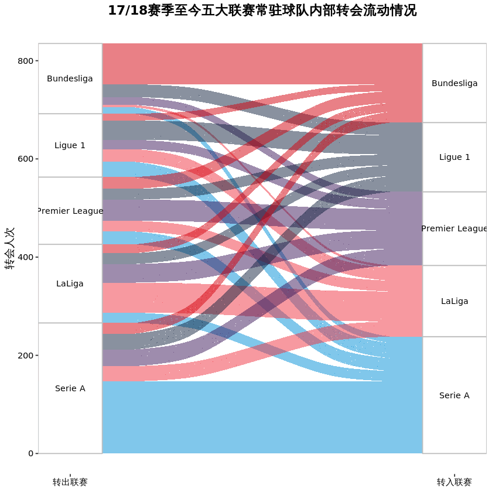

```r
# 将绘图颜色定义为五大联赛logo主色
competition_color <- c("Serie A" = "#008FD7", "LaLiga" = "#EF3340", "Premier League" = "#3D195B", "Ligue 1" = "#12233F", "Bundesliga" = "#D3010C")

# 绘制五大联赛内部转会冲积图
ggplot(within5, aes(y = Transfers, # 转会人次
                    axis1 = Competition0, axis2 = Competition)) + # 从转出联赛到转入联赛
  geom_alluvium(aes(fill = Competition), reverse = FALSE, discern = TRUE) + # 按联赛着色
  geom_stratum(width = 1/6, fill = "white", color = "grey",
               reverse = FALSE, discern = TRUE) + # 设置两端格式
  geom_text(stat = "stratum", aes(label = after_stat(stratum)), reverse = FALSE,
            family = "Songti SC", size = 3, angle = 0, discern = TRUE) + # 设置两端文本标签
  scale_x_discrete(limits = c("转出联赛", "转入联赛"), expand = c(0, 0)) + # 设置x轴标签
  labs(title = "17/18赛季至今五大联赛常驻球队内部转会流动情况", # 设置标题
       y = "转会人次") + # 设置y轴标签
  scale_fill_manual(values = competition_color) + # 设置绘制颜色
  theme(plot.title = element_text(hjust = 0.5, face = "bold"), # 设置标题文本格式
        text = element_text(family = "Songti SC"), # 设置文本字体
        panel.background = element_rect(fill = "white", color = NA), # 设置绘图背景
        panel.border = element_rect(fill = NA, color = NA), # 设置绘图边框
        axis.text = element_text(color = "black"), # 设置轴文本颜色
        legend.position = "none") # 不显示图例
```

五大联赛内部（转出俱乐部和转入俱乐部均为五大联赛常驻球队）的转会流动也体现出相似的现象。意甲的从五大联赛转入的人次少于向五大联赛转出的人次，而英超则相反。这体现出在五大联赛内部，意甲在经历人才流出，而英超如今在技战术层面、政策层面或是经济层面的吸引力更高，在经历人才流入。具体而言，转会去到英超的球员更均匀的来自五大联赛，而转会到意甲和德甲的来自其他联赛的球员较少，以本国联赛球员为主。  
不过除了足球方面的因素，这可能是由语言、生活环境等其他因素导致的。例如，在足球世界，西班牙语和英语是更为通用的语言，球员可能因为语言障碍而选择留在本国或去到其他国家。再比如，西班牙的阳光较之英格兰地区更为充足，球员可能会因为生活体验更好而选择加入西甲联赛。

### 3.3 五大联赛转会合作

#### 3.3.1 绘制转会合作球队数量箱线图

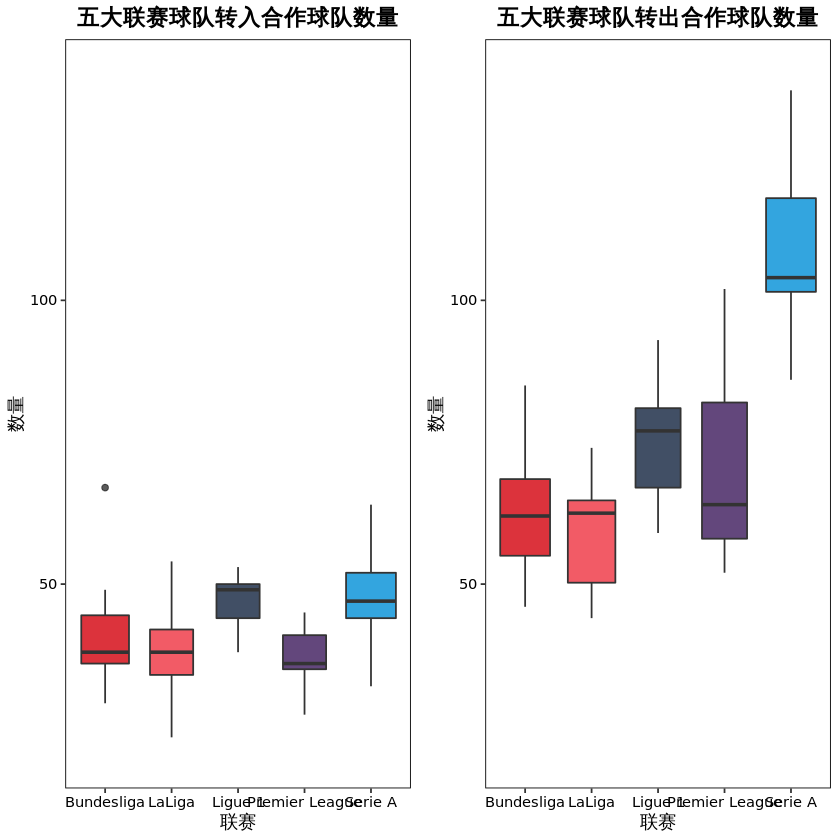

```r
A_p <- ggplot(A, aes(x = Competition0, y = n_clubs, fill = Competition0)) +
  geom_boxplot(varwidth = TRUE, alpha = 0.8) + # 设置箱线图
  scale_fill_manual(values = competition_color) + # 设置绘制颜色
  labs(title = "五大联赛球队转入合作球队数量", # 设置标题
       x = "联赛", y = "数量") + # 设置x轴标签和y轴标签
  ylim(20, 140) + # 设置y轴范围
  theme(plot.title = element_text(hjust = 0.5, face = "bold"), # 设置标题文本格式
        text = element_text(family = "Songti SC"), # 设置文本字体
        panel.background = element_rect(fill = "white", color = NA), # 设置绘图背景
        panel.border = element_rect(fill = NA, color = "black"), # 设置绘图边框
        axis.text = element_text(color = "black"), # 设置轴文本颜色
        legend.position = "none") # 不设置图例

D_p <- ggplot(D, aes(x = Competition0, y = n_clubs, fill = Competition0)) +
  geom_boxplot(varwidth = TRUE, alpha = 0.8) + # 设置箱线图
  scale_fill_manual(values = competition_color) + # 设置绘制颜色
  labs(title = "五大联赛球队转出合作球队数量", # 设置标题
       x = "联赛", y = "数量") + # 设置x轴标签和y轴标签
  ylim(20, 140) + # 设置y轴范围
  theme(plot.title = element_text(hjust = 0.5, face = "bold"), # 设置标题文本格式
        text = element_text(family = "Songti SC"), # 设置文本字体
        panel.background = element_rect(fill = "white", color = NA), # 设置绘图背景
        panel.border = element_rect(fill = NA, color = "black"), # 设置绘图边框
        axis.text = element_text(color = "black"), # 设置轴文本颜色
        legend.position = "none") # 不设置图例

grid.arrange(A_p, D_p, ncol = 2) # 1*2排列
```

### 3.4 足球集团化

#### 3.4.1 城市足球集团和红牛集团定义

```r
# 选取转入或转出曼彻斯特城或莱比锡红牛队的转会数据
MC_D <- PL_D[trimws(PL_D$Club0) == "Manchester City", ]
MC_A <- PL_A[trimws(PL_A$Club0) == "Manchester City", ]
RB_D <- B_D[trimws(B_D$Club0) == "RB Leipzig", ]
RB_A <- B_A[trimws(B_A$Club0) == "RB Leipzig", ]

# 定义城市足球集团和红牛集团的球队列表
City <- c("New York City FC", "Melbourne City FC", "Girona FC",
          "Yokohama F. Marinos", "Montevideo City Torque", "Sichuan Jiuniu",
          "Mumbai City FC", "Esporte Clube Bahia", "Lommel SK", "ESTAC Troyes",
          "Palermo FC") # City Football Group
RB <- c("FC Liefering", "Red Bull Salzburg", "New York Red Bulls",
        "Red Bull Bragantino", "Red Bull Brasil (SP)") # Red Bull Group
```

#### 3.4.2 转入转出或转会租借数据处理

```r
# 定义数据处理函数，参数为数据集、自身球队名、集团球队列表、永久转会或租借标签
process_data <- function(df, self_name , group_list, flag) {
  df <- df %>%
    # 添加转会分类
    mutate(
      class = case_when(
        grepl(self_name, Club) ~ "self", # 交易方名称包含自身球队名，判定为内部青训球队升入
        Club %in% group_list ~ "group", # 交易方名称在集团球队列表内，判定为集团内部转会
        Club %in% big5_clubs ~ "big5", # 交易方名称为五大联赛常驻球队，判定为五大联赛内部转会
        TRUE ~ "non" # 其他情况
      )
    )
  # 如果为永久转会，分类计算转会总人次
  if (flag == "T") {
    df_class <- df %>%
      group_by(class) %>% # 按交易方类别分组
      summarize(Sum = sum(Transfers, na.rm = TRUE)) %>% # 加总转会人次
      arrange(factor(class, levels = c("self", "group", "big5", "non"))) %>% # 按一定顺序排列数据
      mutate(class = factor(class, levels = c("self", "group", "big5", "non"))) # 转为因子变量
  }
  # 如果为永久转会，分类计算转会总人次
  else {
    df_class <- df %>%
      group_by(class) %>% # 按交易方类别分组
      summarize(Sum = sum(Loans, na.rm = TRUE)) %>% # 加总转会人次
      arrange(factor(class, levels = c("self", "group", "big5", "non"))) %>% # 按一定顺序排列数据
      mutate(class = factor(class, levels = c("self", "group", "big5", "non"))) # 转为因子变量
  }
  return(df_class)
}

# 分别处理城市足球集团的永久转会、租借转会的转入和转出情况
MC_A_t <- process_data(MC_A, "Manchester City", City, "T")
MC_D_t <- process_data(MC_D, "Manchester City", City, "T")
MC_A_l <- process_data(MC_A, "Manchester City", City, "L")
MC_D_l <- process_data(MC_D, "Manchester City", City, "L")

# 分别处理红牛集团的永久转会、租借转会的转入和转出情况
RB_A_t <- process_data(RB_A, "RasenBallsport Leipzig", RB, "T")
RB_D_t <- process_data(RB_D, "RasenBallsport Leipzig", RB, "T")
RB_A_l <- process_data(RB_A, "RasenBallsport Leipzig", RB, "L")
RB_D_l <- process_data(RB_D, "RasenBallsport Leipzig", RB, "L")
```

#### 3.4.3 绘制曼彻斯特城和莱比锡红牛队转会华夫图

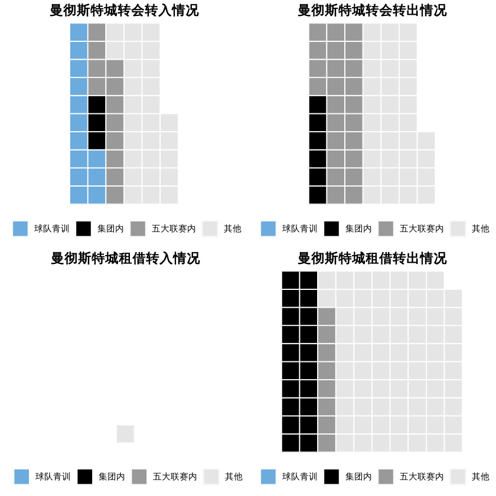

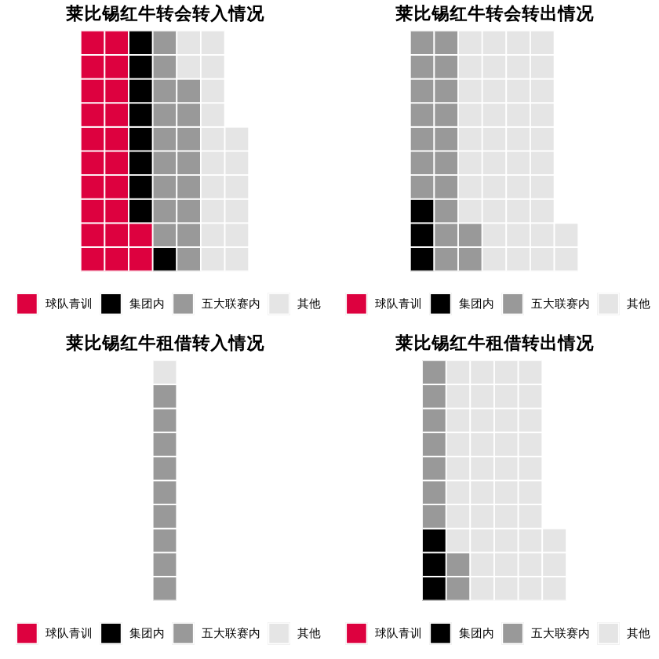

```r
# 设置两队的球队青训、集团内、五大联赛内和其他转会的颜色和标签文本
MC_color <- c("self" = "#6CABDD", "group" = "black", "big5" = "grey60", "non" = "grey90")
RB_color <- c("self" = "#DD013F", "group" = "black", "big5" = "grey60", "non" = "grey90")
class_labels <- c("self" = "球队青训", "group" = "集团内", "big5" = "五大联赛内", "non" = "其他")

# 分别绘制两队永久转会（Transfers）和租借转会的（Loans）的转会交易方联赛分布
# 绘制曼彻斯特城（MC）的转会（tp）转入（A）情况
MC_A_tp <- ggplot(MC_A_t, aes(fill = class, values = Sum)) +
  geom_waffle(n_rows = 10, size = .5, color = "white") +  # 绘制华夫图，设置行数和大小
  scale_fill_manual(values = MC_color, labels = class_labels) +  # 设置绘制颜色和标签文本
  scale_x_discrete(expand = c(0, 0)) +  # 去除x轴两端空白
  scale_y_discrete(expand = c(0, 0)) +  # 去除y轴两端空白
  coord_equal() +  # 设置等比例坐标系
  guides(fill = guide_legend(nrow = 1, byrow = TRUE, title = NULL)) +  # 设置图例
  labs(title = "曼彻斯特城转会转入情况") +  # 设置标题
  theme(plot.title = element_text(hjust = 0.5, face = "bold"), # 设置标题文本格式
        text = element_text(family = "Songti SC"), # 设置文本字体
        panel.background = element_rect(fill = "white", color = NA), # 设置绘图背景
        panel.border = element_rect(fill = NA, color = NA), # 设置绘图边框
        axis.text = element_text(color = "black"), # 设置轴文本颜色
        legend.position = "bottom")  # 设置底部图例
# 绘制曼彻斯特城（MC）的转会（tp）转出（D）情况
MC_D_tp <- ggplot(MC_D_t, aes(fill = class, values = Sum)) +
  geom_waffle(n_rows = 10, size = .5, color = "white") +  # 绘制华夫图，设置行数和大小
  scale_fill_manual(values = MC_color, labels = class_labels) +  # 设置绘制颜色和标签文本
  scale_x_discrete(expand = c(0, 0)) +  # 去除x轴两端空白
  scale_y_discrete(expand = c(0, 0)) +  # 去除y轴两端空白
  coord_equal() +  # 设置等比例坐标系
  guides(fill = guide_legend(nrow = 1, byrow = TRUE, title = NULL)) +  # 设置图例
  labs(title = "曼彻斯特城转会转出情况") +  # 设置标题
  theme(plot.title = element_text(hjust = 0.5, face = "bold"), # 设置标题文本格式
        text = element_text(family = "Songti SC"), # 设置文本字体
        panel.background = element_rect(fill = "white", color = NA), # 设置绘图背景
        panel.border = element_rect(fill = NA, color = NA), # 设置绘图边框
        axis.text = element_text(color = "black"), # 设置轴文本颜色
        legend.position = "bottom")  # 设置底部图例
# 绘制曼彻斯特城（MC）的租借（lp）转入（A）情况
MC_A_lp <- ggplot(MC_A_l, aes(fill = class, values = Sum)) +
  geom_waffle(n_rows = 10, size = .5, color = "white") +  # 绘制华夫图，设置行数和大小
  scale_fill_manual(values = MC_color, labels = class_labels) +  # 设置绘制颜色和标签文本
  scale_x_discrete(expand = c(0, 0)) +  # 去除x轴两端空白
  scale_y_continuous(limits = c(0, 10) # 因数据量不足10，手动设置y轴长度为10保证与其他图大小一致
                     , expand = c(0, 0)) +  # 去除y轴两端空白
  coord_equal() +  # 设置等比例坐标系
  guides(fill = guide_legend(nrow = 1, byrow = TRUE, title = NULL)) +  # 设置图例
  labs(title = "曼彻斯特城租借转入情况") +  # 设置标题
  theme(plot.title = element_text(hjust = 0.5, face = "bold"), # 设置标题文本格式
        text = element_text(family = "Songti SC"), # 设置文本字体
        panel.background = element_rect(fill = "white", color = NA), # 设置绘图背景
        panel.border = element_rect(fill = NA, color = NA), # 设置绘图边框
        axis.text = element_text(color = "black"), # 设置轴文本颜色
        legend.position = "bottom",  # 设置底部图例
        axis.ticks.y = element_blank(),  # 隐藏y轴刻度线
        axis.text.y = element_blank())  # 隐藏y轴文本
# 绘制曼彻斯特城（MC）的租借（lp）转出（D）情况
MC_D_lp <- ggplot(MC_D_l, aes(fill = class, values = Sum)) +
  geom_waffle(n_rows = 10, size = .5, color = "white") +  # 绘制华夫图，设置行数和大小
  scale_fill_manual(values = MC_color, labels = class_labels) +  # 设置绘制颜色和标签文本
  scale_x_discrete(expand = c(0, 0)) +  # 去除x轴两端空白
  scale_y_discrete(expand = c(0, 0)) +  # 去除y轴两端空白
  coord_equal() +  # 设置等比例坐标系
  guides(fill = guide_legend(nrow = 1, byrow = TRUE, title = NULL)) +  # 设置图例
  labs(title = "曼彻斯特城租借转出情况") +  # 设置标题
  theme(plot.title = element_text(hjust = 0.5, face = "bold"), # 设置标题文本格式
        text = element_text(family = "Songti SC"), # 设置文本字体
        panel.background = element_rect(fill = "white", color = NA), # 设置绘图背景
        panel.border = element_rect(fill = NA, color = NA), # 设置绘图边框
        axis.text = element_text(color = "black"), # 设置轴文本颜色
        legend.position = "bottom")  # 设置底部图例

grid.arrange(MC_A_tp, MC_D_tp, MC_A_lp, MC_D_lp, ncol = 2, heights = c(1, 1)) # 2*2排列图片

# 绘制莱比锡红牛（RB）的转会（tp）转入（A）情况
RB_A_tp <- ggplot(RB_A_t, aes(fill = class, values = Sum)) +
  geom_waffle(n_rows = 10, size = .5, color = "white") +  # 绘制华夫图，设置行数和大小
  scale_fill_manual(values = RB_color, labels = class_labels) +  # 设置绘制颜色和标签文本
  scale_x_discrete(expand = c(0, 0)) +  # 去除x轴两端空白
  scale_y_discrete(expand = c(0, 0)) +  # 去除y轴两端空白
  coord_equal() +  # 设置等比例坐标系
  guides(fill = guide_legend(nrow = 1, byrow = TRUE, title = NULL)) +  # 设置图例
  labs(title = "莱比锡红牛转会转入情况") +  # 设置标题
  theme(plot.title = element_text(hjust = 0.5, face = "bold"), # 设置标题文本格式
        text = element_text(family = "Songti SC"), # 设置文本字体
        panel.background = element_rect(fill = "white", color = NA), # 设置绘图背景
        panel.border = element_rect(fill = NA, color = NA), # 设置绘图边框
        axis.text = element_text(color = "black"), # 设置轴文本颜色
        legend.position = "bottom")  # 设置底部图例
# 绘制莱比锡红牛（RB）的转会（tp）转出（D）情况
RB_D_tp <- ggplot(RB_D_t, aes(fill = class, values = Sum)) +
  geom_waffle(n_rows = 10, size = .5, color = "white") +  # 绘制华夫图，设置行数和大小
  scale_fill_manual(values = RB_color, labels = class_labels) +  # 设置绘制颜色和标签文本
  scale_x_discrete(expand = c(0, 0)) +  # 去除x轴两端空白
  scale_y_discrete(expand = c(0, 0)) +  # 去除y轴两端空白
  coord_equal() +  # 设置等比例坐标系
  guides(fill = guide_legend(nrow = 1, byrow = TRUE, title = NULL)) +  # 设置图例
  labs(title = "莱比锡红牛转会转出情况") +  # 设置标题
  theme(plot.title = element_text(hjust = 0.5, face = "bold"), # 设置标题文本格式
        text = element_text(family = "Songti SC"), # 设置文本字体
        panel.background = element_rect(fill = "white", color = NA), # 设置绘图背景
        panel.border = element_rect(fill = NA, color = NA), # 设置绘图边框
        axis.text = element_text(color = "black"), # 设置轴文本颜色
        legend.position = "bottom")  # 设置底部图例
# 绘制莱比锡红牛（RB）的租借（lp）转入（A）情况
RB_A_lp <- ggplot(RB_A_l, aes(fill = class, values = Sum)) +
  geom_waffle(n_rows = 10, size = .5, color = "white") +  # 绘制华夫图，设置行数和大小
  scale_fill_manual(values = RB_color, labels = class_labels) +  # 设置绘制颜色和标签文本
  scale_x_discrete(expand = c(0, 0)) +  # 去除x轴两端空白
  scale_y_discrete(expand = c(0, 0)) +  # 去除y轴两端空白
  coord_equal() +  # 设置等比例坐标系
  guides(fill = guide_legend(nrow = 1, byrow = TRUE, title = NULL)) +  # 设置图例
  labs(title = "莱比锡红牛租借转入情况") +  # 设置标题
  theme(plot.title = element_text(hjust = 0.5, face = "bold"), # 设置标题文本格式
        text = element_text(family = "Songti SC"), # 设置文本字体
        panel.background = element_rect(fill = "white", color = NA), # 设置绘图背景
        panel.border = element_rect(fill = NA, color = NA), # 设置绘图边框
        axis.text = element_text(color = "black"), # 设置轴文本颜色
        legend.position = "bottom",  # 设置底部图例
        axis.ticks.y = element_blank(),  # 隐藏y轴刻度线
        axis.text.y = element_blank())  # 隐藏y轴文本
# 绘制莱比锡红牛（RB）的租借（lp）转出（D）情况
RB_D_lp <- ggplot(RB_D_l, aes(fill = class, values = Sum)) +
  geom_waffle(n_rows = 10, size = .5, color = "white") +  # 绘制华夫图，设置行数和大小
  scale_fill_manual(values = RB_color, labels = class_labels) +  # 设置绘制颜色和标签文本
  scale_x_discrete(expand = c(0, 0)) +  # 去除x轴两端空白
  scale_y_discrete(expand = c(0, 0)) +  # 去除y轴两端空白
  coord_equal() +  # 设置等比例坐标系
  guides(fill = guide_legend(nrow = 1, byrow = TRUE, title = NULL)) +  # 设置图例
  labs(title = "莱比锡红牛租借转出情况") +  # 设置标题
  theme(plot.title = element_text(hjust = 0.5, face = "bold"), # 设置标题文本格式
        text = element_text(family = "Songti SC"), # 设置文本字体
        panel.background = element_rect(fill = "white", color = NA), # 设置绘图背景
        panel.border = element_rect(fill = NA, color = NA), # 设置绘图边框
        axis.text = element_text(color = "black"), # 设置轴文本颜色
        legend.position = "bottom")  # 设置底部图例

grid.arrange(RB_A_tp, RB_D_tp, RB_A_lp, RB_D_lp, ncol = 2, heights = c(1, 1)) # 2*2排列图片
```